A very brief..

Intro to R

[Mladen Čučak](https://github.com/mladencucak/)

*mladencucak@gmail.com*

### Topics

- About R/RStudio
- Basics of programming with R
- Data analysis with `tidyverse`

These materials are based on the APS's “R for Plant Pathologists” [“R for Plant Pathologists”](https://everhartlab.github.io/APS_IntroR_2020/index.html)  
Some inspiration from [J. Bryan's Stat545](https://stat545.com/) and [B. Bohemke's Intro to R](https://github.com/uc-r)  
*All highly recommended*

### Why R

- **Performance**: stable, light and fast
- **Support network**: documentation, community, developers
- **Reproducibility**: anyone anywhere can reproduce results
- **Versatility**: unified solution to *almost* any numerical problem and graphical capabilities
- **Ethics**: accessible to anyone as it is free and open source

### Be strong!

Transition from “point and click” is tough but rewarding

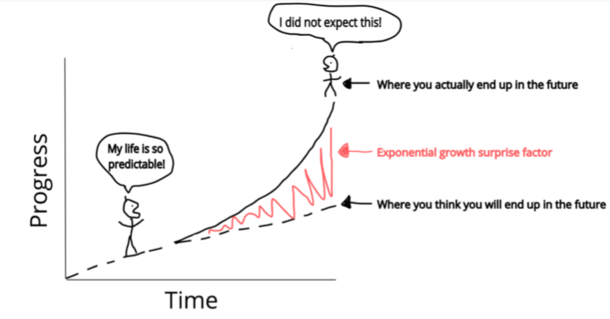

### Baby steps

Help:

- **Google**: just add “with R” at the end of any search
- **Stack Overflow**: programming questions
- **Cross Validated**: scientific questions

Learning:

- “R for Data Science” → https://r4ds.had.co.nz
- R4DS Learning Community → https://rfordatasci.com

### Baby steps

Help:

- **Google**: just add “with R” at the end of any search
- **Stack Overflow**: programming questions
- **Cross Validated**: scientific questions

Learning:

- “R for Data Science” → https://r4ds.had.co.nz
- R4DS Learning Community → https://rfordatasci.com

  There are (too) many resources! So…  
  Stay focused!  
  Don't get overwhelmed!

### Your new best friends

Cheatsheets → https://rstudio.com/resources/cheatsheets/

[figure not shown]

**R** – Statistical programming language

[figure not shown]

/http://www.r-project.org/

**RStudio** – Integrated Development Environment (IDE) makes our life much easier

[figure not shown]

https://rstudio.com/

### It may be described as...

**R** – Engine

[figure not shown]

**RStudio** – Dashboard

[figure not shown]

### R interface

…*is not the friendliest one*…

[figure not shown]

### RStudio (IDE)

[figure not shown]

### Move onto some coding

Move the cursor onto a line with R code and pres:

- (Win)*Ctrl* + *Enter* or
- (MAC)*Cmd* + *Return*.

  *Challenge: Do it with one hand you are not using to hold the mouse!*

  Tips for later:
- Many other keyboard shortcuts in RStudio (Win)*Alt*+*Shift*+*K* or (MAC)*Option*+*Shift*+*K*
- For example, to run an entire script (Win)*Ctrl* + *Shift* + *Enter* or (MAC)*Cmd* + *Shift* + *Return*

### R basics: In R, we have...

**Objects**, where the data is stored.  
Assign with `<-`

```r
x <- 1
y <- 2
x + y
```

```
[1] 3
```

```r
1+3
```

```
[1] 4
```

### R basics: In R, we have...

**Objects**, where the data is stored.  
Assign with `<-`

```r
x <- 1
y <- 2
x + y
```

```
[1] 3
```

```r
1+3
```

```
[1] 4
```

**Functions** which are applied on objects or another functions (i.e. to analyze the data): round brackets!

```r
# I am a comment!!! Just here to help jog the memory later on...
# Let us make a function!
addition <- function(argument_one,
                     argument_two){
  argument_one + argument_two # operations
} # curly brackets define operations

ls() # check content of the environment
```

```
[1] "addition" "x"        "y"
```

```r
addition(argument_one = x,
         argument_two = y)
```

```
[1] 3
```

### R basics: In R, we have...

**Objects**, where the data is stored.  
Assign with `<-`

```r
x <- 1
y <- 2
x + y
```

```
[1] 3
```

```r
1+3
```

```
[1] 4
```

**Functions** which are applied on objects or another functions (i.e. to analyze the data): round brackets!

```r
addition <- function(argument_one, argument_two){
  argument_one + argument_two
}
addition(argument_one = x,argument_two = y)
```

```
[1] 3
```

```r
addition(x, y)# Notice the difference?!
```

```
[1] 3
```

```r
addition(x, y) == x+y #notice double "="
```

```
[1] TRUE
```

```r
all.equal(addition(x, y), x+y) #Same as above, but pre-made
```

```
[1] TRUE
```

### Objects: Vectors

*Vectors* store data of the same type  
(a column of an excel table)

Types of data:

```r
num <- c(50, 60, 65)

char <- c("mouse", "rat", "dog")

fct <- factor("low", "med", "high")

dates <- as.Date(c("02/27/92", "02/27/92", "01/14/92"), "%m/%d/%y")

logical <-  c(FALSE, FALSE, TRUE) # only TRUE or FALSE
```

### Objects: Vectors

*Vectors* store data of the same type  
(a column of an excel table)

Types of data:

```r
num <- c(50, 60, 65)

char <- c("mouse", "rat", "dog")

fct <- factor("low", "med", "high")

dates <- as.Date(c("02/27/92", "02/27/92", "01/14/92"), "%m/%d/%y")

logical <-  c(FALSE, FALSE, TRUE) # only TRUE or FALSE
```

Subsetting - square brackets

```r
num[1] # 1st element
```

```
[1] 50
```

```r
num[num >= 60] # More than or equal
```

```
[1] 60 65
```

```r
char == "dog" # see logical on the left
```

```
[1] FALSE FALSE  TRUE
```

```r
char[logical]
```

```
[1] "dog"
```

```r
char[char == "dog"]
```

```
[1] "dog"
```

### Objects: Dataframes

*Dataframe* is a set of vectors of same length(an entire excel table)

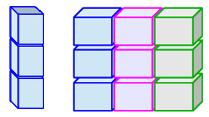

Creating and viewing data frames

```r
df <- data.frame(col_one = num,
                 col_two = char)
print(df)
```

```
  col_one col_two
1      50   mouse
2      60     rat
3      65     dog
```

```r
head(df,1)
```

```
  col_one col_two
1      50   mouse
```

Same logic for indexing, just in 2 dimensions

```r
df[1, 1] # [rows, columns]
```

```
[1] 50
```

```r
df[, 1] # 1st column in the data frame
```

```
[1] 50 60 65
```

```r
df[, -2] # Exclude 2nd column
```

```
[1] 50 60 65
```

```r
df[2:3, "col_two"]
```

```
[1] "rat" "dog"
```

```r
df$col_two
```

```
[1] "mouse" "rat"   "dog"
```

### R packages

Pre-made set of functions for common (and not so common) tasks

[figure not shown]

### A package of R packages: tidyverse

Think of something like Microsoft Office suite

[figure not shown]

`tidyverse` and data analysis cycle

[figure not shown]

### Data import

Several functions within `readr` and `readxl` for different types of files.  
For this workshop, we will use data on [coffee leaf rust from Ethiopia](https://osf.io/xejaz/)

```r
dt <- read_csv(here::here("data", "survey_clean.csv"))
tibble::glimpse(dt, 70)
```

```
Rows: 405
Columns: 13
$ farm            <dbl> 1, 2, 3, 4, 5, 6, 7, 8, 9, 10, 11, 12, 13...
$ region          <chr> "SNNPR", "SNNPR", "SNNPR", "SNNPR", "SNNP...
$ zone            <chr> "Bench Maji", "Bench Maji", "Bench Maji",...
$ district        <chr> "Debub Bench", "Debub Bench", "Debub Benc...
$ lon             <dbl> 35.44250, 35.44250, 35.42861, 35.42861, 3...
$ lat             <dbl> 6.904722, 6.904722, 6.904444, 6.904444, 6...
$ altitude        <dbl> 1100, 1342, 1434, 1100, 1400, 1342, 1432,...
$ cultivar        <chr> "Local", "Mixture", "Mixture", "Local", "...
$ shade           <chr> "Sun", "Mid shade", "Mid shade", "Sun", "...
$ cropping_system <chr> "Plantation", "Plantation", "Plantation",...
$ farm_management <chr> "Unmanaged", "Minimal", "Minimal", "Unman...
$ inc             <dbl> 86.70805, 51.34354, 43.20000, 76.70805, 4...
$ sev2            <dbl> 55.57986, 17.90349, 8.25120, 46.10154, 12...
```

Del Ponte, E. M., & Belachew, K. (2020, June 14). Research Compendium: Altitude is the main driver of coffee leaf rust epidemic - a large-scale survey in Ethiopia. https://doi.org/10.17605/OSF.IO/XEJAZ

### Data transformation

`dplyr` **Functions**  
Six key `dplyr` functions that allow you to solve the vast majority of your data transformation challenges:

| Function | Description |
| --- | --- |
| `filter` | pick observations based on values |
| `select` | pick variables |
| `summarize` | compute statistical summaries |
| `group_by` | perform operations at different levels of your data |
| `arrange` | reorder data |
| `mutate` | create new variables |

**Piping**  
From `magrittr` package.  
Traditional approach:

```r
function(argument_one, argument_two,...)
```

pipe `%\>%` approach:

```r
argument_one %>%
  function(., argument_two,...)
```

### Lets test these

Make small subset of data

```r
(dt_small <-
dt %>%
  select(cultivar, zone, inc) %>%
  group_by(cultivar, zone) %>%
  slice(head(row_number(), 1)) %>%
  filter(
    zone =="Sheka" |zone ==  "Sidama") %>%
  ungroup())
```

```
# A tibble: 6 x 3
  cultivar zone     inc
  <chr>    <chr>  <dbl>
1 Improved Sheka   33.2
2 Improved Sidama  16.5
3 Local    Sheka   81.8
4 Local    Sidama  35.2
5 Mixture  Sheka   29.5
6 Mixture  Sidama  18.6
```

```r
dt_small %>%
  select(cultivar, inc) %>%
  filter(inc <= 17)
```

```
# A tibble: 1 x 2
  cultivar   inc
  <chr>    <dbl>
1 Improved  16.5
```

```r
dt_small %>%
  group_by(cultivar) %>%
  summarize(mean_inc = mean(inc),
            min_weight = min(inc)) %>%
    arrange(desc(mean_inc))
```

```
# A tibble: 3 x 3
  cultivar mean_inc min_weight
  <chr>       <dbl>      <dbl>
1 Local        58.5       35.2
2 Improved     24.8       16.5
3 Mixture      24.1       18.6
```

### Reshaping data: wide

**Important** for data visualization  
Our data subset is in **long format**

```r
dt_small
```

```
# A tibble: 6 x 3
  cultivar zone     inc
  <chr>    <chr>  <dbl>
1 Improved Sheka   33.2
2 Improved Sidama  16.5
3 Local    Sheka   81.8
4 Local    Sidama  35.2
5 Mixture  Sheka   29.5
6 Mixture  Sidama  18.6
```

### Reshaping data: wide

**Important** for data visualization  
Our data subset is in **long format**

```r
dt_small
```

```
# A tibble: 6 x 3
  cultivar zone     inc
  <chr>    <chr>  <dbl>
1 Improved Sheka   33.2
2 Improved Sidama  16.5
3 Local    Sheka   81.8
4 Local    Sidama  35.2
5 Mixture  Sheka   29.5
6 Mixture  Sidama  18.6
```

Change it to **wide** format with `tidyr`

- `names_from`: column to columnS
- `values_from`: column to values

```r
(dt_small_wide <-
dt_small %>%
  pivot_wider(names_from = "zone",
              values_from = "inc"))
```

```
# A tibble: 3 x 3
  cultivar Sheka Sidama
  <chr>    <dbl>  <dbl>
1 Improved  33.2   16.5
2 Local     81.8   35.2
3 Mixture   29.5   18.6
```

### Reshaping data: long

Can we do it the other way around?

```r
dt_small_wide
```

```
# A tibble: 3 x 3
  cultivar Sheka Sidama
  <chr>    <dbl>  <dbl>
1 Improved  33.2   16.5
2 Local     81.8   35.2
3 Mixture   29.5   18.6
```

Change it to **long** format with `pivot_longer()`

```r
dt_small_wide %>%
  pivot_longer(cols =
                 c("Sheka", "Sidama"),
               names_to = "zone",
               values_to = "inc")
```

```
# A tibble: 6 x 3
  cultivar zone     inc
  <chr>    <chr>  <dbl>
1 Improved Sheka   33.2
2 Improved Sidama  16.5
3 Local    Sheka   81.8
4 Local    Sidama  35.2
5 Mixture  Sheka   29.5
6 Mixture  Sidama  18.6
```

Congratulations!!

[figure not shown]

So, the painful part is done, enjoy the rest!